# Homework 4

Victor Aluko

11 March 2017

## Exercise 1

The presentation focuses on creating effective visualizations. The speaker talks about the different categories of data (categorical, ordinal, quantitative etc.) and the appropriate visualizations for these categories of data. The speaker mentions that each visual representation comprises of marks (points, lines, boxes etc) and channels (position, color, size).

For categorical data, color hue would be appropriate for use in representating the data while color hue becomes very difficult to understand for ordinal or quantitative data.

It also mentions how values like Electric Current, Color saturation, Black-and-White lightness produce more noticeable results when varied compared to Area, Loudness and Brightness which lead to decreased perception as they are increased. Length on the other hand is more stable and easier to understand relative to the data increase.

The presentation also talks about the importance of Separability and Integrality. If separability is the aim of the visualization, then one channel and one mark should be suffient to represent the data. If the focus is on Integrality, then it is fine to use multiple channels or marks, as the separability decreases with increased number of channels/marks.

The presentation also talks about how it may be much clearer sometimes to use Curve maps over heat maps. With the line plots of curve maps, it becomes much easier to see the changes over the axis rather than the heat map changes.

The presentation then discusses 3D-models for visualization and Animations. The challenges associated with using these visualization styles and alternatives to them. 3D-models are strongly discouraged while multiple visualizations are encouraged over animations, as it is easier to follow and compare rather than depending on memory.

## Exercise 2

I used a random seeded generator in a python script to generate random data from the CSV file. I limited to 200,000 records so that the data would be sufficient for analysis. Although some columns are not necessary for the plotting, I left them in the CSV used for this report just to show what the uncleaned data would produce.

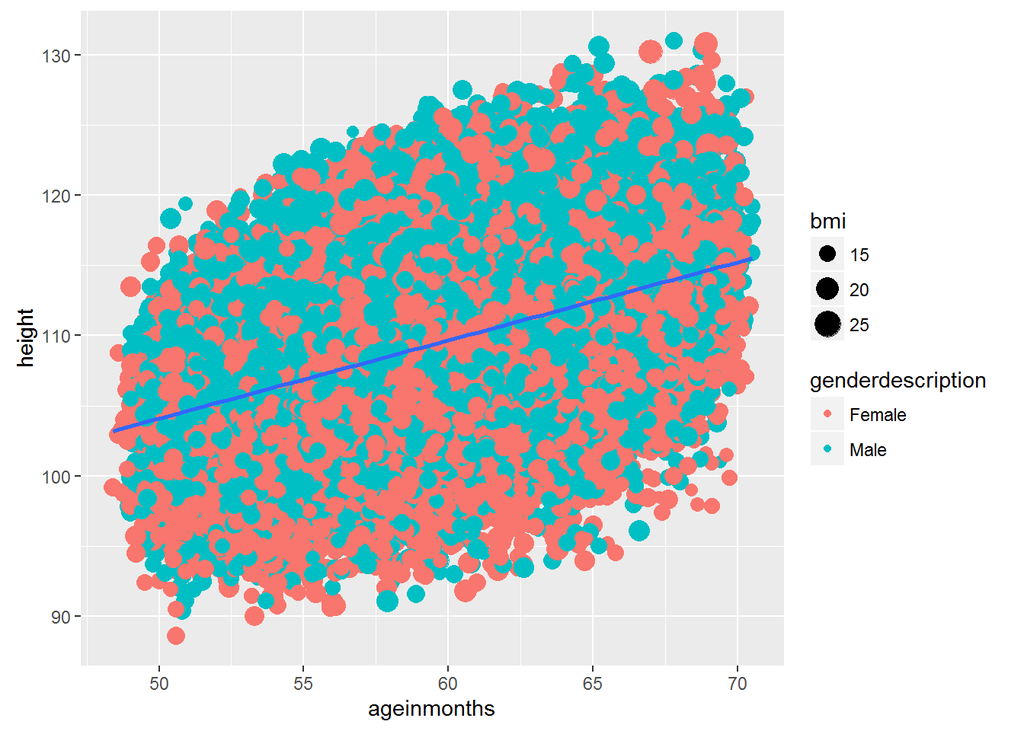

```r
plot_height_1 <- ggplot(ukdata_sub_height, aes(x = ageinmonths, y = height)) + geom_point(aes(color = genderdescription, size = bmi)) + geom_smooth(method = "lm", se = TRUE)
plot_height_1
```

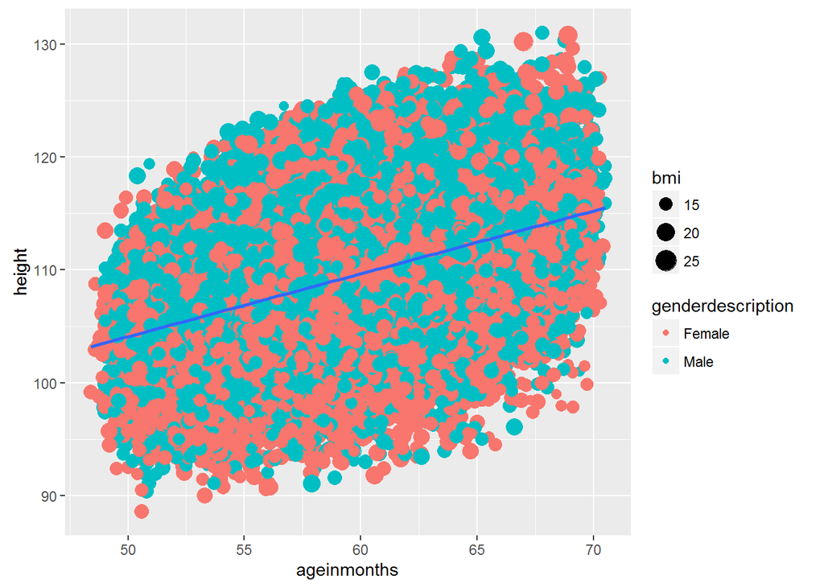

```r
ukdata_sub_weight <- subset(ukdata, ageinmonths < 100 & height > 0)
plot_weight_1 <- ggplot(ukdata_sub_weight, aes(x = ageinmonths, y = height)) + geom_point(aes(color = genderdescription, size = bmi)) + geom_smooth(method = "lm", se = TRUE)
plot_weight_1
```

The graph from the initial plot did not have so many BMI values. Hence, I reduced to 20,000 records and tried to plot the graphs again

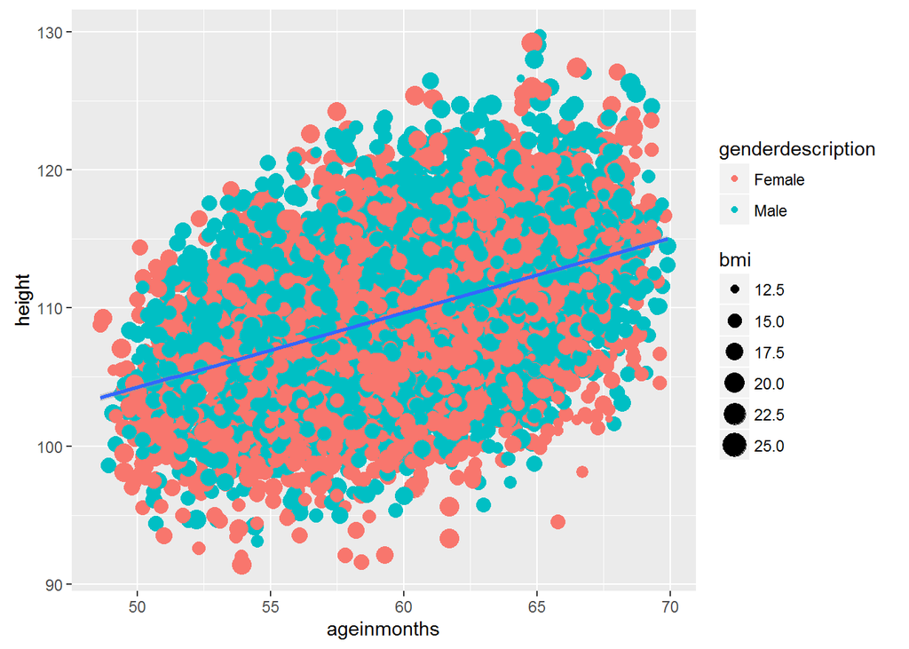

```r
ukdata_sub_height_2 <- subset(ukdata2, ageinmonths < 100 & height > 0)
plot_height_2 <- ggplot(ukdata_sub_height_2, aes(x = ageinmonths, y = height)) + geom_point(aes(color = genderdescription, size = bmi)) + geom_smooth(method = "lm", se = TRUE)
plot_height_2
```

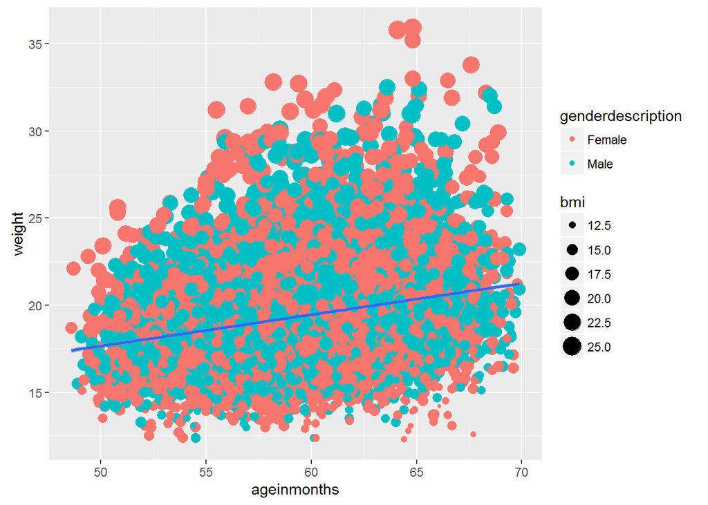

```r
ukdata_sub_weight_2 <- subset(ukdata2, ageinmonths < 100 & weight > 0)
plot_weight_2 <- ggplot(ukdata_sub_weight_2, aes(x = ageinmonths, y = weight)) + geom_point(aes(color = genderdescription, size = bmi)) + geom_smooth(method = "lm", se = TRUE)
plot_weight_2
```

With this plot, the BMI values are more pronounced and it is easier to see their impact even though the graph is still cluttered.

## Exercise 3

For this task, I studied the data and identified the Itemsets that had support over 5. The table of the itemsets with their respective supports are below:

| Itemset | Support |
| --- | --- |
| A | 8 |
| B | 4 |
| C | 7 |
| D | 11 |
| E | 3 |
| F | 12 |
| G | 8 |
| H | 8 |

After this run, I generated all the possiblities for the selected itemsets with support over 5. I had a total of 15 itemsets. I then generated the support for these items, as seen in the table below. I was able to determine that 10 items had support over 5. The items are:

| Itemset | Support |
| --- | --- |
| A C | 5 |
| A D | 6 |
| A F | 6 |
| A G | 4 |
| A H | 3 |
| C D | 5 |
| C F | 5 |
| C G | 4 |
| C H | 3 |
| D F | 8 |
| D G | 6 |
| D H | 6 |
| F G | 8 |
| F H | 6 |
| G H | 3 |

| Itemset | Support |
| --- | --- |
| A C D | 4 |
| A C F | 3 |
| A D F | 4 |
| C D F | 3 |
| C D G | 2 |
| A D G | 3 |
| D F G | 6 |
| A D H | 3 |
| C D H | 2 |
| D F H | 4 |
| A F G | 4 |
| A F H | 2 |
| C F G | 4 |
| C F H | 1 |

## Exercise 4

Based on the data from Exercise 3, I generated the Confidence and Lift values for the double itemsets i.e. the itemsets that have 2 elements. In order to generate the Confidence, I used the formula below:

> Confidence of {A-C} = Support of {A-C} / Support of {A}

The formula for Lift is as shown below:

> Lift of {A-C} = Support of {A-C} / (Support of {A} * Support of {C})

The Table of Confidence and Lift for the Second run is given below:

[output not shown]

From the above table also, it is clear that A-C, C-G and F-G have the highest lift values. This means that C is like to come after A while G is like to come in the same itemset as C or F.

## Exercise 5

First, we need to extract the Association rules using the apriori algortihm. I am using the helper code provided for this homework

```
## Apriori
##
## Parameter specification:
##  confidence minval smax arem  aval originalSupport maxtime support minlen
##         0.8    0.1    1 none FALSE            TRUE       5     0.1      1
##  maxlen target   ext
##      10  rules FALSE
##
## Algorithmic control:
##  filter tree heap memopt load sort verbose
##     0.1 TRUE TRUE  FALSE TRUE    2    TRUE
##
## Absolute minimum support count: 220
##
## set item appearances ...[0 item(s)] done [0.00s].
## set transactions ...[10 item(s), 2201 transaction(s)] done [0.00s].
## sorting and recoding items ... [9 item(s)] done [0.00s].
## creating transaction tree ... done [0.00s].
## checking subsets of size 1 2 3 4 done [0.00s].
## writing ... [27 rule(s)] done [0.00s].
## creating S4 object  ... done [0.00s].
```

```
## Apriori
##
## Parameter specification:
##  confidence minval smax arem  aval originalSupport maxtime support minlen
##         0.8    0.1    1 none FALSE            TRUE       5     0.1      1
##  maxlen target   ext
##      10  rules FALSE
##
## Algorithmic control:
##  filter tree heap memopt load sort verbose
##     0.1 TRUE TRUE  FALSE TRUE    2    TRUE
##
## Absolute minimum support count: 220
##
## set item appearances ...[2 item(s)] done [0.00s].
## set transactions ...[10 item(s), 2201 transaction(s)] done [0.00s].
## sorting and recoding items ... [9 item(s)] done [0.00s].
## creating transaction tree ... done [0.00s].
## checking subsets of size 1 2 3 4 done [0.00s].
## writing ... [2 rule(s)] done [0.00s].
## creating S4 object  ... done [0.00s].
```

From the association, we can see that for Survival, Survival is No for Sex of Male and Class of 3rd. The only case where survival is Yes is when it is Adult Female.

We can plot the distribution to show the relationships of the Antecedence and Consequences using a matrix plot as seen below

```
## Itemsets in Antecedent (LHS)
##  [1] "{}"
##  [2] "{Class=2nd}"
##  [3] "{Class=1st}"
##  [4] "{Sex=Female}"
##  [5] "{Class=3rd}"
##  [6] "{Survived=Yes}"
##  [7] "{Class=Crew}"
##  [8] "{Survived=No}"
##  [9] "{Sex=Male}"
## [10] "{Sex=Female,Survived=Yes}"
## [11] "{Class=3rd,Sex=Male}"
## [12] "{Class=3rd,Survived=No}"
## [13] "{Sex=Male,Survived=Yes}"
## [14] "{Class=Crew,Survived=No}"
## [15] "{Class=Crew,Sex=Male}"
## [16] "{Class=Crew,Age=Adult}"
## [17] "{Sex=Male,Survived=No}"
## [18] "{Age=Adult,Survived=No}"
## [19] "{Class=3rd,Sex=Male,Survived=No}"
## [20] "{Class=3rd,Age=Adult,Survived=No}"
## [21] "{Class=3rd,Sex=Male,Age=Adult}"
## [22] "{Class=Crew,Sex=Male,Survived=No}"
## [23] "{Class=Crew,Age=Adult,Survived=No}"
## Itemsets in Consequent (RHS)
## [1] "{Age=Adult}"   "{Sex=Male}"    "{Survived=No}"
```

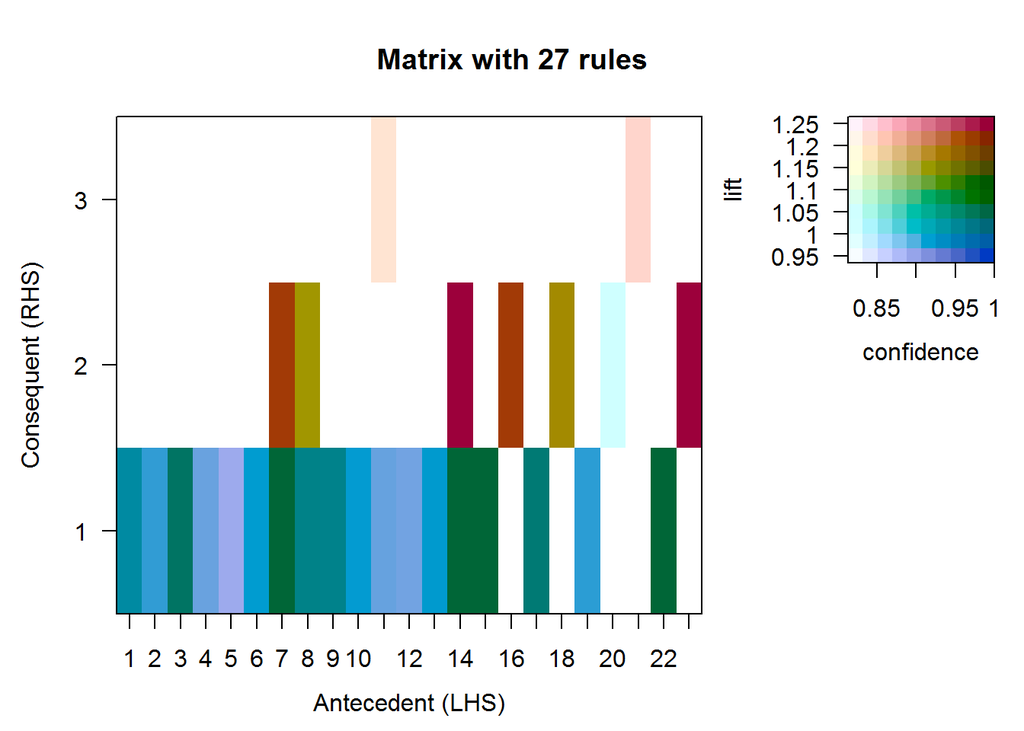

This shows us that the most consistent relationship is Adult-Male-No

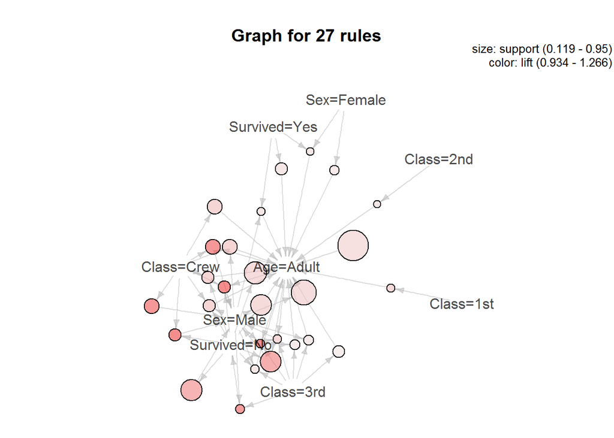

For study, I will look at the rule below:

> {Class=Crew,Age=Adult,Survived=No} => {Sex=Male}

It has a Support of 0.3044071. This means that the rule has a 30% popularity. That is means about 660 records fall under this association rule.

The rule also has a Confidence of 0.9955423. THis means 99% confidence of the RHS being associated with the LHS. Almost a certainty. So if we have an Adult Crew that did not Survive, then with a 99% confidence, we can say the Sex is Male.